# Clustering

Partioning Technique: You will request a particular number of clusters to the algorithm. The algorithm will put every case in one of those clusters. Outliers will affect output.

```r
#uploading merged data file from Github
link = 'https://raw.githubusercontent.com/Group-6-542/EmilyRepository/50e2502dfe3fde3a633f8ca193eb0c6ff76aafe5/mergedGroupDataFinal.csv'
myfile = url(link)

#reading in data
fromPy = read.csv(file = myfile)

#reset indexes in R since they differ from python
row.names(fromPy) = NULL
```

Preparing Data: Create a distance matrix

step 1: Explore variables that will be used for clustering

```r
dfClus = fromPy[,c( 'casesReported', 'numberOfReturns', 'avgAGI', 'culturalSpaces')]
#make sure that column names match the column names in the merged file
#we are using 4 variables for the subset dfClus
#You can also create a subset of more or less variables

summary(dfClus) #summary of results
```

```
 casesReported  numberOfReturns     avgAGI       culturalSpaces
 Min.   : 670   Min.   :  590   Min.   : 50.01   Min.   : 4.00
 1st Qu.:1194   1st Qu.:11030   1st Qu.: 70.94   1st Qu.: 9.00
 Median :1752   Median :13660   Median : 94.82   Median :23.00
 Mean   :2128   Mean   :14530   Mean   : 94.57   Mean   :30.72
 3rd Qu.:2958   3rd Qu.:17560   3rd Qu.:108.84   3rd Qu.:38.00
 Max.   :5361   Max.   :28150   Max.   :202.57   Max.   :88.00
```

Step 2: Rescale units if needed into a new variable

```r
#Above summary shows different ranges (max value of variables greatly varies)
#so through standardization all values will have mean of zero

dfClus=scale(dfClus)
#standardization scale.You do not have any units and avoids mistakes in clusters

summary(dfClus)
```

```
 casesReported     numberOfReturns       avgAGI          culturalSpaces
 Min.   :-1.2490   Min.   :-2.2172   Min.   :-1.297133   Min.   :-1.0347
 1st Qu.:-0.8002   1st Qu.:-0.5567   1st Qu.:-0.688000   1st Qu.:-0.8411
 Median :-0.3222   Median :-0.1384   Median : 0.007106   Median :-0.2989
 Mean   : 0.0000   Mean   : 0.0000   Mean   : 0.000000   Mean   : 0.0000
 3rd Qu.: 0.7108   3rd Qu.: 0.4819   3rd Qu.: 0.415474   3rd Qu.: 0.2819
 Max.   : 2.7692   Max.   : 2.1662   Max.   : 3.144025   Max.   : 2.2181
```

Step 3: Rename subset indexes and verify what your input is:

```r
row.names(dfClus)=fromPy$zipcode
#rownames are now zipcodes

head(dfClus)
```

```
      casesReported numberOfReturns       avgAGI culturalSpaces
98101     2.7692024      -1.0561643  1.210335367      0.9402123
98102    -0.3222130       0.2146557  0.007105718     -0.4151184
98103     1.6487892       2.1662153 -0.266184307      1.7921345
98104     1.1862332      -1.2645216  0.118901835      2.1793718
98105     0.7108285       0.1383110  0.406081896      1.2887259
98106    -1.2490381      -0.3229378 -1.295246636     -0.8798033
```

Step 4: Set random seed:

```r
set.seed(999) #for randomization, fair way to start. This makes sure that what one person computes, the other also gets similar result. So now everytime it starts from the same point. Replicability of results
```

Step 5: Decide distance method and compute distance matrix:

```r
#library(cluster) - you do not need to use library if you are using cluster::daisy function

dfClus_D=cluster::daisy(x=dfClus) #distance calculated
dfClus_D #using distance for partioning technique
```

```
Dissimilarities :
          98101     98102     98103     98104     98105     98106     98107     98108     98109     98112
98102 3.8021725
98103 3.8137826 3.5552901
98104 2.2969431 3.3477236 3.5045909
98105 2.5361309 2.0335366 2.3869495 1.7520478
98106 5.1258439 1.7493041 4.7740450 4.2632727 3.4133363
98107 2.8928200 1.4066019 2.8445935 2.4779154 1.4549792 2.4824013
98108 4.2145152 1.5920857 3.8587574 3.0597974 2.4132326 1.3348240 1.5952407
98109 2.7137261 1.4085986 2.6989060 2.1909393 0.6637162 2.9140117 1.1119347 2.0903816
98112 3.7532834 3.2141028 5.1368032 4.3442950 3.4223831 4.6251592 3.8250990 4.5349771 3.0739989
98115 4.0492021 1.6403101 2.4790404 3.9039567 2.2014296 3.0175638 1.9790111 2.7354528 1.8274707 3.6678118
98116 4.1816881 0.7006149 4.1129001 3.5254750 2.3919121 1.5284795 1.9480626 1.6274666 1.8094267 3.1852592
98117 3.2023147 1.3031160 3.1598543 3.4364643 2.1324901 2.6324798 1.1577039 2.3091788 1.5986229 3.4031520
98118 4.6529344 1.6471664 2.9042610 3.8281754 2.4776322 2.0956783 1.9057408 1.7370004 2.1702729 4.6356650
98119 3.6296648 0.7403008 4.0319439 3.2691849 2.1560604 2.0156932 1.7495447 1.9266070 1.5281244 2.6838066
98121 2.8172280 1.6852741 3.9888381 2.4000714 1.7025584 2.9208216 1.9078715 2.3822903 1.3155484 2.3908187
98122 4.2139865 2.7440111 2.4794237 2.6455313 1.8051342 3.5018236 2.5035691 2.4920505 2.0933389 4.7533272
98125 3.9306827 1.7612390 3.2557869 3.9950171 2.7605920 2.5016246 1.5364644 2.3095317 2.3068509 4.3315248
98126 4.4445581 1.2279754 4.5379721 3.7687113 2.9184253 0.7952933 2.0082130 1.2588913 2.3663354 3.9306170
98133 5.4494226 1.9445557 3.9712393 4.9110855 3.5183549 1.8851237 2.6950725 2.3626717 3.0399194 4.8095846
98134 4.3730980 2.7405050 5.7651246 3.6762956 3.4791439 2.9287549 3.3570960 2.9442752 3.0928417 3.1982676
98136 3.9776540 1.3515609 4.7601690 3.6067504 2.8091310 1.8317678 2.2065314 2.0303146 2.2200188 2.9899870
98144 3.4834828 0.7945868 3.2220594 2.9616271 1.8127465 1.8346539 0.7236689 1.2210367 1.2959368 3.7219530
98146 4.8430804 1.4523782 4.5879260 4.1571944 3.2253399 0.4302010 2.2199221 1.3544510 2.6834360 4.3423123
98199 4.4343897 1.6583609 4.9643180 4.0771064 3.0680584 2.3608611 2.8473016 2.7013958 2.4912009 2.4614728
          98115     98116     98117     98118     98119     98121     98122     98125     98126     98133
98102
98103
98104
98105
98106
98107
98108
98109
98112
98115
98116 2.2078170
98117 1.5543067 1.9609862
98118 1.5346563 2.0146628 2.1111408
```

[output cut: 24 more lines]

```
98118
98119
98121
98122
98125
98126
98133
98134
98136 1.6264210
98144 3.0553932 1.7378693
98146 2.8797172 1.5867202 1.5545830
98199 1.7696598 1.0529959 2.3402704 2.1730006

Metric :  euclidean
Number of objects : 25
```

Partioning Technique applied now

Step 6: Indicate the number of clusters you require and apply function

```r
NumCluster=4 #number of clusters or categories that data will be sorted into

#pam is a partioning technique
#library cluster has the function pam so can use that also
res.pam = cluster::pam(x=dfClus_D,
              k = NumCluster,
              cluster.only = F) #get all information
```

Clustering Results

Step 7: Adding results to original data frame

```r
fromPy$pam=as.factor(res.pam$clustering)
#convert into Categorical data
#pam variable created - can see in fromPy now
```

Step 8: Query Data frame as needed Example: Finding zipcodes in cluster 1

```r
fromPy[fromPy$pam==1,'zipcode'] # this shows zipcodes belonging to cluster group 1
```

```
[1] 98101 98103 98104 98105 98109 98122
```

Step 9: Report: Table of Clusters

```r
table(fromPy$pam)
```

```
1 2 3 4
6 8 4 7
```

```r
#shows how many zipcodes in each cluster, so looking at table below: cluster 1 has 6 zipcodes, cluster 2 has 8 and so on
```

Evaluate Results

Step 10: Report: Average Silhouettes

|  | cluster | size | ave.sil.width |
| --- | --- | --- | --- |
| 1 | 1 | 6 | 0.09 |
| 2 | 2 | 8 | 0.19 |
| 3 | 3 | 4 | 0.39 |
| 4 | 4 | 7 | 0.19 |

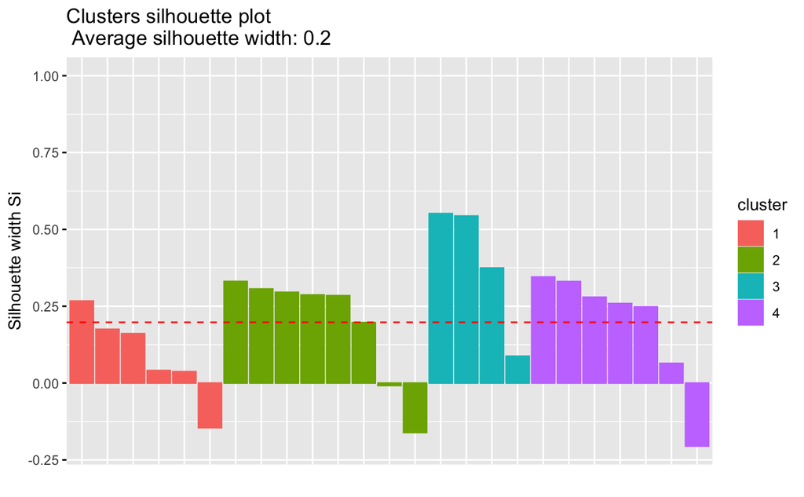

```r
library(factoextra) #install this library and call it
#res.pam shows the silinfo

fviz_silhouette(res.pam)
```

```r
#silhouette is a measurement of how good was a cluster
#higher value of silhouette - well clustered
#lower value of silhouette - wrongly/poorly clustered
#negative value of silhouette - should not be there
```

Report: Detecting Anomalies

Step 11: Save individual silhouettes:

```r
pamEval=data.frame(res.pam$silinfo$widths) #turning into a data frame
#pamEval data frame shows what cluster you belong and who is your neighbor

head(pamEval)
```

|  | cluster | neighbor | sil_width |
| --- | --- | --- | --- |
| 98104 | 1 | 4 | 0.26695231 |
| 98101 | 1 | 4 | 0.17488698 |
| 98105 | 1 | 4 | 0.16072352 |
| 98103 | 1 | 4 | 0.04084077 |
| 98122 | 1 | 4 | 0.03717080 |
| 98109 | 1 | 4 | -0.14501376 |

```r
#now we can check in pamEval which ones are poorly (negatively) clusetred
```

Step 12: Request negative silhouettes: The ones that are poorly clustered.

```r
pamEval[pamEval$sil_width<0,]
```

|  | cluster | neighbor | sil_width |
| --- | --- | --- | --- |
| 98109 | 1 | 4 | -0.145013758 |
| 98116 | 2 | 3 | -0.007904669 |
| 98102 | 2 | 4 | -0.160917926 |
| 98108 | 4 | 3 | -0.205013324 |

```r
#Now the table below shows that 98109 has closest neighbor 4 but it was placed in cluster 1 or 98116 had closest neighbor 3 but it was put in cluster 2
```

Partioning technique complete.